# Презентация по лабораторной работе №4

Дискреционное разграничение прав в Linux. Расширенные атрибуты

Лушин А.А.

Российский университет дружбы народов, Москва, Россия

Факультет Физико-математических и естественных наук

18 февраля 2005

# Информация

## Докладчик

- Лушин Артём Андреевич
- Бакалавр направления компьютерные и информационные науки
- Кафедра теории вероятности и кибербезопасности
- Российский университет дружбы народов
- Редактор Первого Федерального канала
- lusin5745@gmail.com

# Вводная часть

## Цели и задачи

- Получение практических навыков работы в консоли с расширенными атрибутами файлов.

# Ход работы

## Выдача атрибутов

Чтобы выдать атрибуты какому-то файлу, нам необходимо иметь аккаунт с административными правами или же перейти в root-пользователя. Всего у нас на выбор 22 атрибута. По ходу лабораторной мы проверяем всего лишь два.

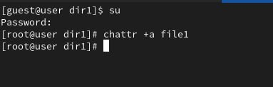

## Проверка атрибутов

После того, как мы выдали атрибуты, нам необходимо убедиться в правильности. Используя команду “lsattr” мы можем проверить, какие атрибуты есть в нашем файле.

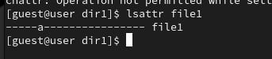

## Использование атрибутов

У каждого из 22 атрибутов есть своё значение и функции. Мы опробовали атрибут “а”. После его активации я не смог вносить текст в файл, менять название файла, удалять файл. Я могу только прочитать текст и добавить запись к тому тексту, который находится в файле.

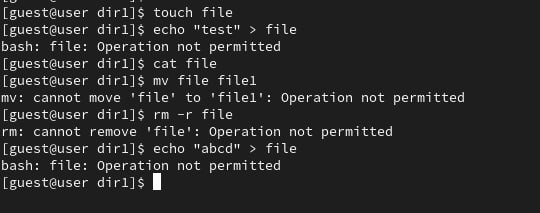

## Отключение атрибутов

Чтобы отключить атрибуты нам необходимо снова зайти на аккаунт правами администратора. Затем указываем команду “chattr -a имя_файла”. То есть в данном случае мы отключаем атрибут “а”. Чтобы отключить другие атрибуты, просто меняем букву.

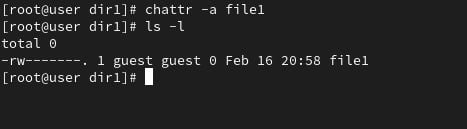

## Атрибут “i”

Мы подключаем второй атрибут “i”. Так же прогоняем всевозможные функции. Как и с атрибутом “а”, мы не можем вносить текст в файл, менять название файла, удалять файл. Но можем прочитать содержимое файла.

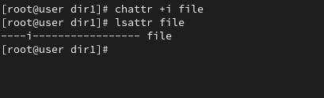

## Таблица сравнения

На основе проведённых опытов я составил таблицу с возможностями атрибутов. При использовании атрибута “а” и “i” большинство возможностей совпали. То есть при включенных атрибутах я могу только читать файл и в атрибуте “а” дописывать его. Зависит это от того, что атрибут “а” можно открыть только в режиме добавления для записи. А файл с атрибутом “i” не может быть изменён. Так же файл нельзя открыть в режиме записи.

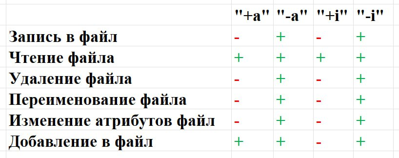

# Результаты

## Вывод

Я получил практические навыки работы в консоли с расширенными атрибутами файлов.